# PCA example

## Set up

Load the wine dataset from rattle.data package and ggplot2/dplyr packages

```r
library(rattle.data)
library(ggplot2)
data("wine")
knitr::kable(wine[1:10,])
```

| Type | Alcohol | Malic | Ash | Alcalinity | Magnesium | Phenols | Flavanoids | Nonflavanoids | Proanthocyanins | Color | Hue | Dilution | Proline |
| --- | --- | --- | --- | --- | --- | --- | --- | --- | --- | --- | --- | --- | --- |
| 1 | 14.23 | 1.71 | 2.43 | 15.6 | 127 | 2.80 | 3.06 | 0.28 | 2.29 | 5.64 | 1.04 | 3.92 | 1065 |
| 1 | 13.20 | 1.78 | 2.14 | 11.2 | 100 | 2.65 | 2.76 | 0.26 | 1.28 | 4.38 | 1.05 | 3.40 | 1050 |
| 1 | 13.16 | 2.36 | 2.67 | 18.6 | 101 | 2.80 | 3.24 | 0.30 | 2.81 | 5.68 | 1.03 | 3.17 | 1185 |
| 1 | 14.37 | 1.95 | 2.50 | 16.8 | 113 | 3.85 | 3.49 | 0.24 | 2.18 | 7.80 | 0.86 | 3.45 | 1480 |
| 1 | 13.24 | 2.59 | 2.87 | 21.0 | 118 | 2.80 | 2.69 | 0.39 | 1.82 | 4.32 | 1.04 | 2.93 | 735 |
| 1 | 14.20 | 1.76 | 2.45 | 15.2 | 112 | 3.27 | 3.39 | 0.34 | 1.97 | 6.75 | 1.05 | 2.85 | 1450 |
| 1 | 14.39 | 1.87 | 2.45 | 14.6 | 96 | 2.50 | 2.52 | 0.30 | 1.98 | 5.25 | 1.02 | 3.58 | 1290 |
| 1 | 14.06 | 2.15 | 2.61 | 17.6 | 121 | 2.60 | 2.51 | 0.31 | 1.25 | 5.05 | 1.06 | 3.58 | 1295 |
| 1 | 14.83 | 1.64 | 2.17 | 14.0 | 97 | 2.80 | 2.98 | 0.29 | 1.98 | 5.20 | 1.08 | 2.85 | 1045 |
| 1 | 13.86 | 1.35 | 2.27 | 16.0 | 98 | 2.98 | 3.15 | 0.22 | 1.85 | 7.22 | 1.01 | 3.55 | 1045 |

## PCA unscaled

Unless there’s a good reason not to, PCA should always be carried out on scaled data, otherwise the variables with the biggest variance tend to dominate. See what happens if we don’t do this first

Do the pca

```r
wine_pca <- prcomp(as.matrix(wine[,-1]))
summary(wine_pca)
```

```
## Importance of components:
##                             PC1      PC2     PC3     PC4     PC5     PC6
## Standard deviation     314.9632 13.13527 3.07215 2.23409 1.10853 0.91710
## Proportion of Variance   0.9981  0.00174 0.00009 0.00005 0.00001 0.00001
## Cumulative Proportion    0.9981  0.99983 0.99992 0.99997 0.99998 0.99999
##                           PC7    PC8    PC9   PC10   PC11   PC12    PC13
## Standard deviation     0.5282 0.3891 0.3348 0.2678 0.1938 0.1452 0.09057
## Proportion of Variance 0.0000 0.0000 0.0000 0.0000 0.0000 0.0000 0.00000
## Cumulative Proportion  1.0000 1.0000 1.0000 1.0000 1.0000 1.0000 1.00000
```

PC1 is accounting for almost all of the variance, so this PCA Isn’t going to be very useful.

Now do some standard plots:

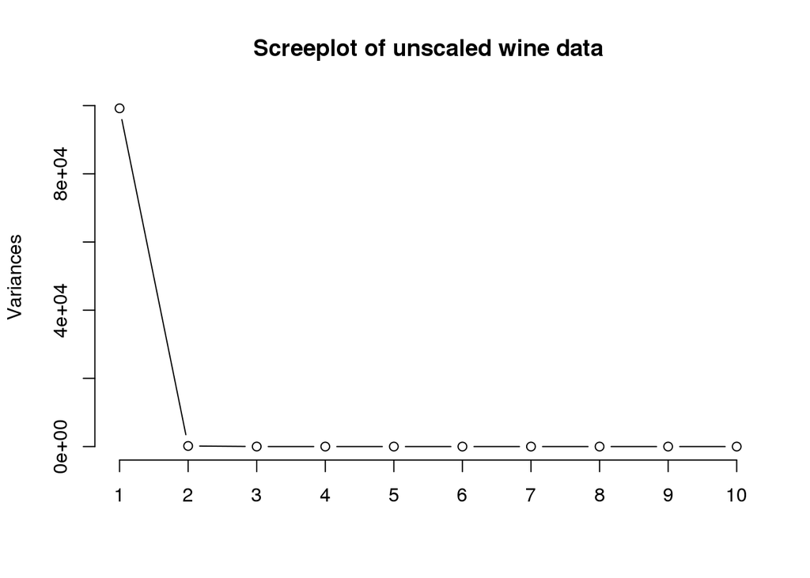

```r
screeplot(wine_pca, type = "lines", main="Screeplot of unscaled wine data")
```

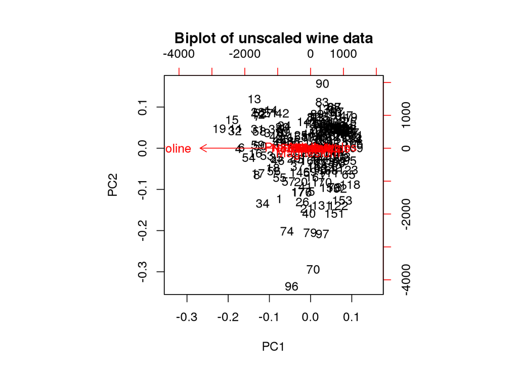

```r
biplot(wine_pca, main='Biplot of unscaled wine data')
```

In the screeplot we see again how PC1 accounts for almost all of the variance. One of the variables is probably skewing things, which is why we need to scale.

Let’s now do our own plots to make them look nicer. First extract the rotated data from the `prcomp` object into a data frame and add in the wine type from the original data:

```r
pca_data <- as.data.frame(wine_pca$x)
pca_data$Type = wine$Type
knitr::kable(pca_data[1:10,])
```

| PC1 | PC2 | PC3 | PC4 | PC5 | PC6 | PC7 | PC8 | PC9 | PC10 | PC11 | PC12 | PC13 | Type |
| --- | --- | --- | --- | --- | --- | --- | --- | --- | --- | --- | --- | --- | --- |
| -318.56298 | -21.4921307 | 3.1307347 | 0.2501138 | 0.6770782 | -0.5680810 | 0.6196418 | -0.1995554 | 0.7012803 | 0.0950076 | 0.0887340 | -0.0385476 | 0.0802644 | 1 |
| -303.09742 | 5.3647177 | 6.8228355 | 0.8640347 | -0.4860960 | -0.0143399 | -0.1088651 | 0.6047144 | 0.2867168 | 0.0457820 | 0.0397782 | -0.0571916 | 0.0135927 | 1 |
| -438.06113 | 6.5373094 | -1.1132230 | -0.9124107 | 0.3806514 | -0.6724037 | -0.7858189 | -0.5008857 | 0.0245467 | 0.2089598 | 0.2377700 | -0.0487979 | -0.0354082 | 1 |
| -733.24014 | -0.1927290 | -0.9172570 | 0.5412506 | 0.8586623 | -0.5991217 | -0.0187702 | 0.1904283 | 0.0542768 | -0.5316836 | -0.0960438 | -0.1663531 | 0.0163444 | 1 |
| 11.57143 | -18.4899946 | -0.5544221 | -1.3608961 | 0.2764416 | -0.7688835 | 0.3099758 | 0.1190910 | -0.1958430 | -0.0617706 | 0.3164664 | -0.0071180 | 0.0152776 | 1 |
| -703.23119 | 0.3321587 | 0.9493753 | 0.3599938 | 0.1568271 | -0.0610114 | -0.0260758 | 0.0978094 | -0.3880962 | -0.1019532 | -0.0306408 | -0.0316141 | 0.0748641 | 1 |
| -542.97158 | 13.5189666 | 2.1269428 | -0.0555661 | -0.4836597 | -0.0377117 | 0.5465700 | -0.3417773 | 0.5701891 | 0.0628100 | 0.2176257 | -0.0970746 | -0.0029760 | 1 |
| -548.40186 | -11.4494324 | 0.0404924 | -1.3494538 | -0.8525909 | 0.0928853 | 0.5894683 | 0.4719631 | 0.5450288 | -0.0150469 | 0.0444906 | -0.0222266 | 0.0400074 | 1 |
| -298.03686 | 8.1801578 | 3.8809752 | 0.9106430 | 0.3114890 | -0.3210026 | 1.1304455 | -0.4814293 | -0.3534031 | 0.0485355 | -0.0382506 | -0.0306064 | 0.0162965 | 1 |
| -298.04955 | 7.1015429 | 1.5584553 | 1.6770420 | 1.5584161 | -0.1749195 | 0.2194007 | 0.2466564 | 0.4251687 | 0.0145872 | -0.0896268 | -0.0094652 | -0.0245828 | 1 |

Now let’s do our plot:

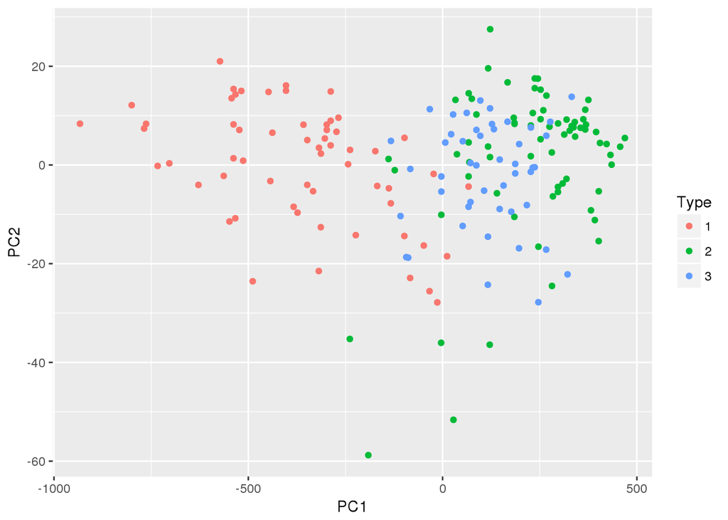

```r
ggplot(pca_data, aes(x=PC1, y=PC2, color=Type)) + geom_point()
```

Even not doing PCA properly we still see some seperation between classes. Now let’s do it properly.

## PCA scaled

Do the pca but set center and scale variables to true.

```r
wine_pca_scaled <- prcomp(as.matrix(wine[,-1]), center = TRUE, scale=TRUE)
summary(wine_pca_scaled)
```

```
## Importance of components:
##                          PC1    PC2    PC3     PC4     PC5     PC6     PC7
## Standard deviation     2.169 1.5802 1.2025 0.95863 0.92370 0.80103 0.74231
## Proportion of Variance 0.362 0.1921 0.1112 0.07069 0.06563 0.04936 0.04239
## Cumulative Proportion  0.362 0.5541 0.6653 0.73599 0.80162 0.85098 0.89337
##                            PC8     PC9   PC10    PC11    PC12    PC13
## Standard deviation     0.59034 0.53748 0.5009 0.47517 0.41082 0.32152
## Proportion of Variance 0.02681 0.02222 0.0193 0.01737 0.01298 0.00795
## Cumulative Proportion  0.92018 0.94240 0.9617 0.97907 0.99205 1.00000
```

This time we see that the variance is more evenly spread between PC’s.

Now do some standard plots again:

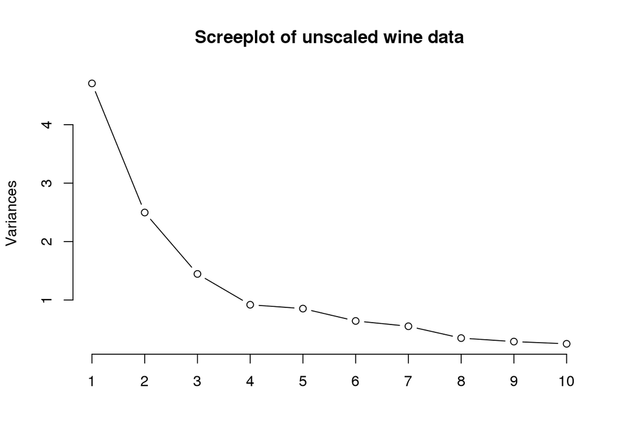

```r
screeplot(wine_pca_scaled, type = "lines", main="Screeplot of unscaled wine data")
```

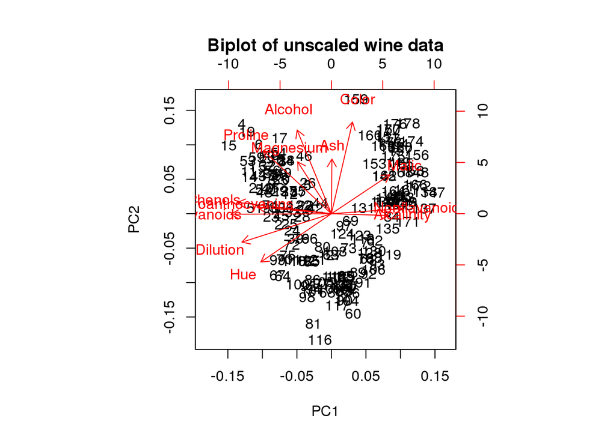

```r
biplot(wine_pca_scaled, main='Biplot of unscaled wine data')
```

In the screeplot we see again that the variance is better spread, and we can usefully use several of these.

```r
pca_data_scaled <- as.data.frame(wine_pca_scaled$x)
pca_data_scaled$Type = wine$Type
knitr::kable(pca_data_scaled[1:10,])
```

| PC1 | PC2 | PC3 | PC4 | PC5 | PC6 | PC7 | PC8 | PC9 | PC10 | PC11 | PC12 | PC13 | Type |
| --- | --- | --- | --- | --- | --- | --- | --- | --- | --- | --- | --- | --- | --- |
| -3.307421 | 1.4394023 | -0.1652728 | 0.2150246 | 0.6910933 | 0.2232504 | 0.5947488 | -0.0649559 | -0.6396384 | 1.0180840 | 0.4502932 | 0.5392891 | -0.0660523 | 1 |
| -2.203250 | -0.3324551 | -2.0207571 | 0.2905387 | -0.2569299 | 0.9245123 | 0.0536243 | -1.0215343 | 0.3079780 | 0.1592521 | 0.1422560 | 0.3871456 | 0.0036263 | 1 |
| -2.509661 | 1.0282507 | 0.9800541 | -0.7228632 | -0.2503270 | -0.5477310 | 0.4230122 | 0.3432479 | 1.1745213 | 0.1130420 | 0.2858665 | 0.0005819 | 0.0216554 | 1 |
| -3.746497 | 2.7486184 | -0.1756962 | -0.5663856 | -0.3109644 | -0.1141091 | -0.3822590 | -0.6417831 | -0.0523966 | 0.2387392 | -0.7574476 | -0.2413388 | -0.3684442 | 1 |
| -1.006071 | 0.8673840 | 2.0209873 | 0.4086131 | 0.2976180 | 0.4053761 | 0.4428253 | -0.4155283 | -0.3258998 | -0.0781460 | 0.5244656 | -0.2160547 | -0.0791403 | 1 |
| -3.041674 | 2.1164309 | -0.6276254 | 0.5141870 | -0.6302409 | -0.1230834 | 0.4005239 | -0.3937826 | 0.1517181 | -0.1017089 | -0.4044444 | -0.3783654 | 0.1447470 | 1 |
| -2.442201 | 1.1715453 | -0.9743464 | 0.0656453 | -1.0248709 | 0.6183764 | 0.0527419 | 0.3708876 | 0.4557303 | 1.0137039 | 0.4411889 | 0.1408326 | -0.2710137 | 1 |
| -2.053644 | 1.6044371 | 0.1458704 | 1.1892533 | 0.0766872 | 1.4357561 | 0.0322845 | -0.2323236 | -0.1230233 | 0.7335308 | -0.2927291 | 0.3785951 | -0.1098539 | 1 |
| -2.503811 | 0.9154885 | -1.7659874 | -0.0561121 | -0.8897471 | 0.1288177 | 0.1249327 | 0.4981726 | -0.6048829 | 0.1736169 | 0.5075013 | -0.6334624 | 0.1416839 | 1 |
| -2.745882 | 0.7872170 | -0.9814789 | -0.3483988 | -0.4672351 | -0.1629320 | -0.8718927 | -0.1501559 | -0.2298408 | 0.1789154 | -0.0124431 | 0.5487788 | -0.0423354 | 1 |

Now let’s do our modified plot:

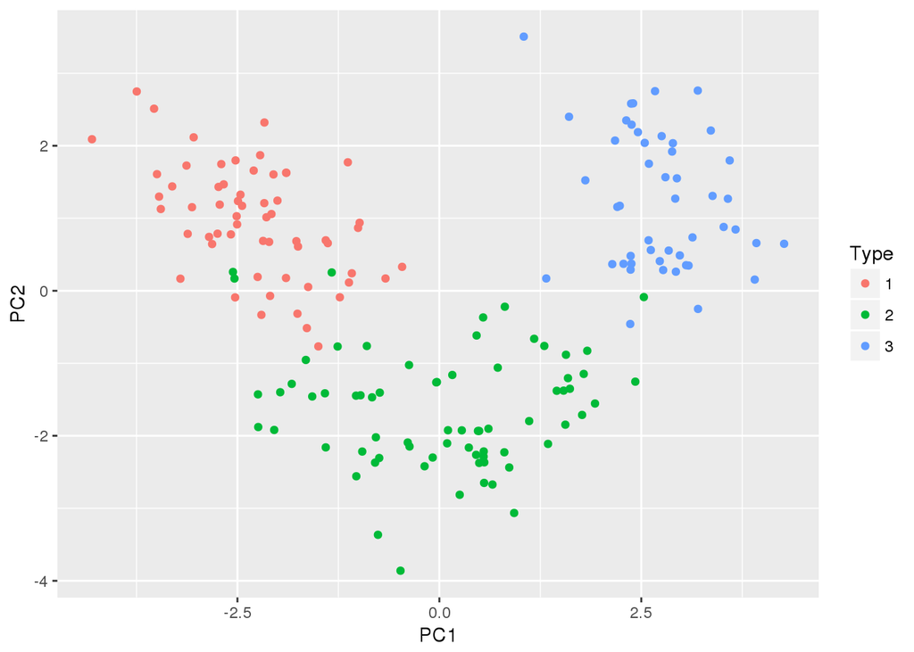

```r
ggplot(pca_data_scaled, aes(x=PC1, y=PC2, color=Type)) + geom_point()
```

Now we see nice seperation between classes. This gives us some confidence that there is some structure in the data that we can use to build a meaningful predictive model. Note that it is also worth looking at other PCs not just 1 and 2 since these might explain the variance more relevant to your class of interest.